# Trump Vote and Vaccination

John Goldin

2022-05-17 12:00:00 (a work in progress)

Charles Gaba (and [others](https://www.npr.org/sections/health-shots/2021/12/05/1059828993/data-vaccine-misinformation-trump-counties-covid-death-rate)) have used county level data to look at the correlation between the Trump share of the 2020 vote and the percentage of the population who have been vaccinated.

The goal of this exercise is to reproduce that plot for towns in Connecticut and to look at some variations on the same theme.

#### Percent Two Doses (or 1 J&J)

The denominator for the vaccination rate is the 2020 decennial census. The numerator is based on vaccination information from the [Department of Public Health](https://data.ct.gov/Health-and-Human-Services/COVID-19-Vaccinations-by-Town-and-Age-Group/gngw-ukpw). Their data comes from [CT WiZ](https://portal.ct.gov/DPH/Immunizations/ALL-ABOUT-CT-WiZ). “[all COVID-19 vaccine doses administered must be reported to CT WiZ, CT’s Immunization Information System, within 24 hours.](https://portal.ct.gov/DPH/Immunizations/COVID-19-Vaccine-Providers)” Unfortunately it doesn’t follow that the vaccine information is perfect. The DPH site notes that vaccines by federal providers such as the DOD may not be included. A Connecticut resident who is vaccinated in another state would not be included automatically. If vaccination information does get into the patients local Connecticut electronic health record via their health care provider it may still be uploaded to CT WiZ. The home address as recorded in WiZ might not correspond to where the individual is counted by the Census. For example college students might be in the Census with their college address while their vaccination record might be recorded with their home address.

“Fully vaccinated” here refers to one dose of J&J or two doses of Pfizer or Moderna vaccines.

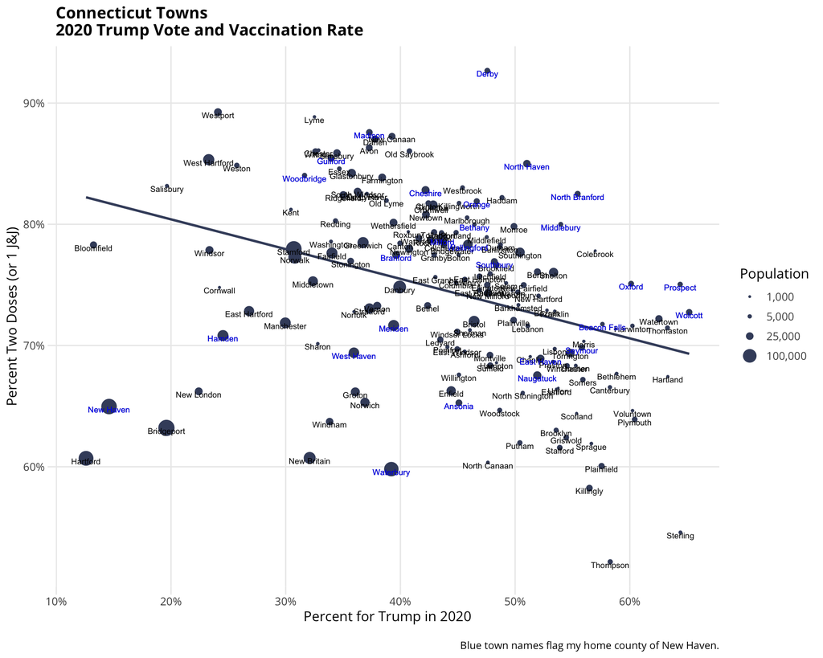

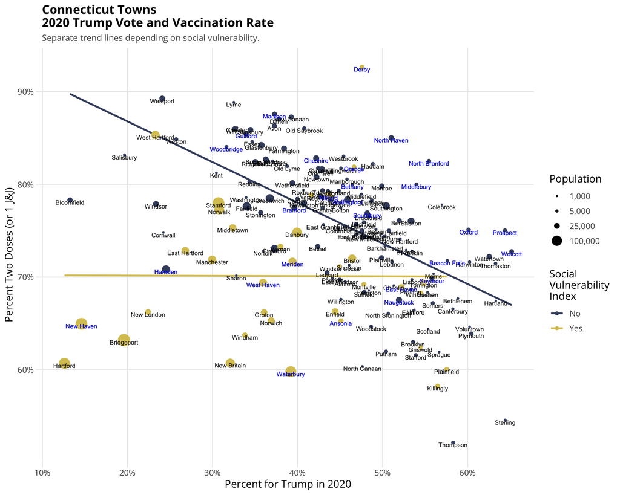

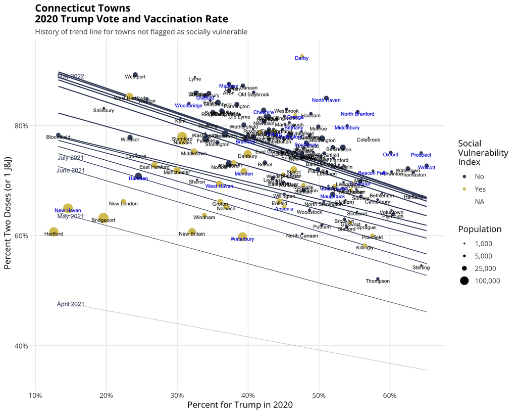